# LeslieSalt_Analysis

Siva Bulusu

October 5, 2019

## Problem Statement

In 1968, the city of Mountain View, California, began the necessary legal proceedings to acquire a parcel of land owned by the Leslie Sal Company. The Leslie property contained 246.8 acres and was located right on the San Francisco Bay. The land had been used for salt evaporation and had an elevation of exactly sea level. However, the property was diked so that the waters from the bay park were kept out. The city of Mountain View intended to fill the property and use it for a city park.

Ultimately, it fell into the courts to determine a fair market value for the property. Appraisers were hired, but what made the processes difficult was that there were few sales of byland property and none of them corresponded exactly to the characteristics of the Leslie property. The experts involved decided to build a regression model to better understand the factors that might influence market valuation. They collected data on 31 byland properties that were sold during the previous 10 years. In addition to the transaction price for each property, they collected data oina large number of other factors, including size, time of sale, elevation, location, and access to sewers. A listing of these data, including only those variables deemed relevant for this exercise. A description of the variables is provided below.

Variable Name Description Price Sales price in $000 per acre County San Mateo=0, Santa Clara =1 Size Size of the property in acres Elevation Average Elevation in foot above sea level Sewer Distance (in feet) to nearest sewer connection Date Date of sale counting backward from current time (in months) Flood Subject to flooding by tidal action =1; otherwise =0 Distance Distance in miles from Leslie Property (in almost all cases, this is toward San Francisco

## Solution

Price is the dependent variable. All others (County, Size, Elevation, Sewer, Date, Flood, Distance) are independent variables.

Include required libraries.

```r
library(readxl)
```

```r
library(ggplot2)
library(car)
library(lmtest)
library("ggplot2")
```

Import data and have a look.

```r
LSdata <- read_excel("D:/SivaBulusu/LeslieSalt/Dataset_LeslieSalt.xlsx", sheet = "Data")
View(LSdata)
```

Check for structure of data.

```r
str(LSdata)
```

```
## Classes 'tbl_df', 'tbl' and 'data.frame':    31 obs. of  8 variables:
##  $ Price    : num  4.5 10.6 1.7 5 5 3.3 5.7 6.2 19.4 3.2 ...
##  $ County   : num  1 1 0 0 0 1 1 1 1 1 ...
##  $ Size     : num  138.4 52 16.1 1695.2 845 ...
##  $ Elevation: num  10 4 0 1 1 2 4 4 20 0 ...
##  $ Sewer    : num  3000 0 2640 3500 1000 10000 0 0 1300 6000 ...
##  $ Date     : num  -103 -103 -98 -93 -92 -86 -68 -64 -63 -62 ...
##  $ Flood    : num  0 0 1 0 1 0 0 0 0 0 ...
##  $ Distance : num  0.3 2.5 10.3 14 14 0 0 0 1.2 0 ...
```

County and Flood columns are integers here. They can be factored as these variables represent county name and yes/no values for flood.

Check for summary of data

```r
summary(LSdata)
```

```
##      Price           County            Size           Elevation
##  Min.   : 1.70   Min.   :0.0000   Min.   :   6.90   Min.   : 0.000
##  1st Qu.: 5.35   1st Qu.:0.0000   1st Qu.:  20.35   1st Qu.: 2.000
##  Median :11.70   Median :1.0000   Median :  51.40   Median : 4.000
##  Mean   :11.95   Mean   :0.6129   Mean   : 139.97   Mean   : 4.645
##  3rd Qu.:16.05   3rd Qu.:1.0000   3rd Qu.: 104.10   3rd Qu.: 7.000
##  Max.   :37.20   Max.   :1.0000   Max.   :1695.20   Max.   :20.000
##      Sewer            Date             Flood           Distance
##  Min.   :    0   Min.   :-103.00   Min.   :0.0000   Min.   : 0.000
##  1st Qu.:    0   1st Qu.: -63.50   1st Qu.:0.0000   1st Qu.: 0.850
##  Median :  900   Median : -59.00   Median :0.0000   Median : 4.900
##  Mean   : 1981   Mean   : -58.65   Mean   :0.1613   Mean   : 5.132
##  3rd Qu.: 3450   3rd Qu.: -51.00   3rd Qu.:0.0000   3rd Qu.: 5.500
##  Max.   :10000   Max.   :  -4.00   Max.   :1.0000   Max.   :16.500
```

Check for missing values in the dataset.

```r
sapply(LSdata,function(x){sum(is.na(x))})
```

```
##     Price    County      Size Elevation     Sewer      Date     Flood
##         0         0         0         0         0         0         0
##  Distance
##         0
```

There are no missing values in any of the columns.

Factor County and Flood columns. Replace appropriate values as per given inputs. Summarize data once again.

```r
#Replace appropriate values in County column
LSdata$County <- factor(LSdata$County,
                        levels=c("0","1"),
                        labels=c("San Mateo", "Santa Clara"))

#Replace appropriate values in Flood column
LSdata$Flood <- factor(LSdata$Flood,
                       levels=c("0","1"),
                       labels=c("No", "Yes" ))

#check for the changes
str(LSdata)
```

```
## Classes 'tbl_df', 'tbl' and 'data.frame':    31 obs. of  8 variables:
##  $ Price    : num  4.5 10.6 1.7 5 5 3.3 5.7 6.2 19.4 3.2 ...
##  $ County   : Factor w/ 2 levels "San Mateo","Santa Clara": 2 2 1 1 1 2 2 2 2 2 ...
##  $ Size     : num  138.4 52 16.1 1695.2 845 ...
##  $ Elevation: num  10 4 0 1 1 2 4 4 20 0 ...
##  $ Sewer    : num  3000 0 2640 3500 1000 10000 0 0 1300 6000 ...
##  $ Date     : num  -103 -103 -98 -93 -92 -86 -68 -64 -63 -62 ...
##  $ Flood    : Factor w/ 2 levels "No","Yes": 1 1 2 1 2 1 1 1 1 1 ...
##  $ Distance : num  0.3 2.5 10.3 14 14 0 0 0 1.2 0 ...
```

```r
summary(LSdata)
```

```
##      Price               County        Size           Elevation
##  Min.   : 1.70   San Mateo  :12   Min.   :   6.90   Min.   : 0.000
##  1st Qu.: 5.35   Santa Clara:19   1st Qu.:  20.35   1st Qu.: 2.000
##  Median :11.70                    Median :  51.40   Median : 4.000
##  Mean   :11.95                    Mean   : 139.97   Mean   : 4.645
##  3rd Qu.:16.05                    3rd Qu.: 104.10   3rd Qu.: 7.000
##  Max.   :37.20                    Max.   :1695.20   Max.   :20.000
##      Sewer            Date         Flood       Distance
##  Min.   :    0   Min.   :-103.00   No :26   Min.   : 0.000
##  1st Qu.:    0   1st Qu.: -63.50   Yes: 5   1st Qu.: 0.850
##  Median :  900   Median : -59.00            Median : 4.900
##  Mean   : 1981   Mean   : -58.65            Mean   : 5.132
##  3rd Qu.: 3450   3rd Qu.: -51.00            3rd Qu.: 5.500
##  Max.   :10000   Max.   :  -4.00            Max.   :16.500
```

```r
View(LSdata)
```

Now the County and Flood columns are factored and also the values are readable in appropriate format.

Create linear model with Price as dependent variable and all other columns as independent variables. Check the summary for understanding the model.

```r
Regmodel1 <- lm(Price~.,data=LSdata)
summary(Regmodel1)
```

```
##
## Call:
## lm(formula = Price ~ ., data = LSdata)
##
## Residuals:
##    Min     1Q Median     3Q    Max
## -5.169 -2.957 -0.256  2.070 13.031
##
## Coefficients:
##                     Estimate Std. Error t value Pr(>|t|)
## (Intercept)        2.364e+01  3.829e+00   6.174 2.68e-06 ***
## CountySanta Clara -8.789e+00  3.652e+00  -2.407 0.024532 *
## Size              -6.043e-03  3.501e-03  -1.726 0.097702 .
## Elevation          5.193e-01  2.386e-01   2.177 0.040030 *
## Sewer             -9.573e-04  4.169e-04  -2.296 0.031126 *
## Date               8.508e-02  4.865e-02   1.749 0.093646 .
## FloodYes          -1.202e+01  2.989e+00  -4.020 0.000536 ***
## Distance           1.858e-01  3.395e-01   0.547 0.589386
## ---
## Signif. codes:  0 '***' 0.001 '**' 0.01 '*' 0.05 '.' 0.1 ' ' 1
##
## Residual standard error: 4.431 on 23 degrees of freedom
## Multiple R-squared:  0.747,  Adjusted R-squared:   0.67
## F-statistic: 9.703 on 7 and 23 DF,  p-value: 1.351e-05
```

R-squared and Adjusted R-squared are good. However, Distance is having least significance.

Check for outliers by using qqplot.

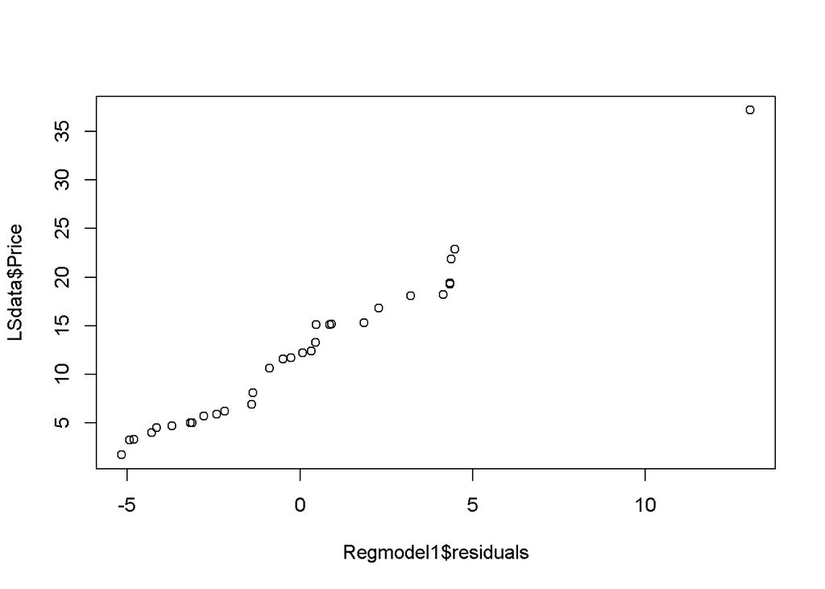

```r
qqplot(Regmodel1$residuals,LSdata$Price)
```

One value in Price column is above 35. All others are equally distributed. By checking in excel provided, the outlier with price more than 35 is identified as 26th row. This will be handled while building next models. The ow will not be considered for better results.

Build another model without Distance column. Check the summary.

```r
Regmodel2 <- lm(Price ~. -Distance, data=LSdata)
summary(Regmodel2)
```

```
##
## Call:
## lm(formula = Price ~ . - Distance, data = LSdata)
##
## Residuals:
##     Min      1Q  Median      3Q     Max
## -5.6249 -2.8459 -0.5266  1.9702 12.6368
##
## Coefficients:
##                     Estimate Std. Error t value Pr(>|t|)
## (Intercept)        2.521e+01  2.514e+00  10.025 4.68e-10 ***
## CountySanta Clara -1.005e+01  2.789e+00  -3.604 0.001423 **
## Size              -5.425e-03  3.265e-03  -1.662 0.109585
## Elevation          4.995e-01  2.324e-01   2.150 0.041869 *
## Sewer             -1.054e-03  3.724e-04  -2.829 0.009272 **
## Date               7.842e-02  4.641e-02   1.690 0.104029
## FloodYes          -1.219e+01  2.927e+00  -4.166 0.000347 ***
## ---
## Signif. codes:  0 '***' 0.001 '**' 0.01 '*' 0.05 '.' 0.1 ' ' 1
##
## Residual standard error: 4.366 on 24 degrees of freedom
## Multiple R-squared:  0.7437, Adjusted R-squared:  0.6797
## F-statistic: 11.61 on 6 and 24 DF,  p-value: 4.257e-06
```

R-squared and Adjusted R-squared are good. However Date and Size are having least significance.

Build another model without Distance column handling the outliers (26th row identified)). Check the summary.

```r
Regmodel3 <- lm(Price ~. -Distance, data=LSdata[-26,])
summary(Regmodel3)
```

```
##
## Call:
## lm(formula = Price ~ . - Distance, data = LSdata[-26, ])
##
## Residuals:
##     Min      1Q  Median      3Q     Max
## -5.1098 -2.0090 -0.4809  2.2081  5.1694
##
## Coefficients:
##                     Estimate Std. Error t value Pr(>|t|)
## (Intercept)       22.2741624  1.9916393  11.184 8.89e-11 ***
## CountySanta Clara -5.7200830  2.3006652  -2.486  0.02061 *
## Size              -0.0022859  0.0025410  -0.900  0.37766
## Elevation          0.4972991  0.1737789   2.862  0.00882 **
## Sewer             -0.0007418  0.0002871  -2.584  0.01661 *
## Date               0.1110019  0.0354663   3.130  0.00470 **
## FloodYes          -8.4899819  2.3413474  -3.626  0.00142 **
## ---
## Signif. codes:  0 '***' 0.001 '**' 0.01 '*' 0.05 '.' 0.1 ' ' 1
##
## Residual standard error: 3.265 on 23 degrees of freedom
## Multiple R-squared:  0.7824, Adjusted R-squared:  0.7256
## F-statistic: 13.78 on 6 and 23 DF,  p-value: 1.307e-06
```

R-squared and Adjusted R-squared are good. However, Size is having least significance.

```r
Regmodel4 <- lm(Price ~. -Distance-Size-Date, data=LSdata)
summary(Regmodel4)
```

```
##
## Call:
## lm(formula = Price ~ . - Distance - Size - Date, data = LSdata)
##
## Residuals:
##      Min       1Q   Median       3Q      Max
## -11.9477  -3.1059   0.1916   2.1658  13.8554
##
## Coefficients:
##                     Estimate Std. Error t value Pr(>|t|)
## (Intercept)        2.063e+01  2.605e+00   7.921 2.13e-08 ***
## CountySanta Clara -1.090e+01  2.492e+00  -4.375 0.000175 ***
## Elevation          5.428e-01  2.803e-01   1.937 0.063704 .
## Sewer             -1.207e-03  4.347e-04  -2.777 0.010032 *
## FloodYes          -1.318e+01  3.230e+00  -4.081 0.000379 ***
## ---
## Signif. codes:  0 '***' 0.001 '**' 0.01 '*' 0.05 '.' 0.1 ' ' 1
##
## Residual standard error: 5.283 on 26 degrees of freedom
## Multiple R-squared:  0.5936, Adjusted R-squared:  0.5311
## F-statistic: 9.495 on 4 and 26 DF,  p-value: 7.183e-05
```

R-squared and Adjusted R-squared are dropped when Date and Size are both removed.

Build another model without Distance, Size columns handling the outliers (26th row identified)). Check the summary.

```r
Regmodel5 <- lm(Price ~. -Distance-Size, data=LSdata[-26,])
summary(Regmodel5)
```

```
##
## Call:
## lm(formula = Price ~ . - Distance - Size, data = LSdata[-26,
##     ])
##
## Residuals:
##     Min      1Q  Median      3Q     Max
## -5.0186 -2.2651 -0.3114  2.1549  5.1596
##
## Coefficients:
##                     Estimate Std. Error t value Pr(>|t|)
## (Intercept)       22.0187525  1.9634490  11.214 5.01e-11 ***
## CountySanta Clara -4.4613706  1.8189990  -2.453  0.02183 *
## Elevation          0.5086667  0.1726287   2.947  0.00704 **
## Sewer             -0.0006846  0.0002789  -2.455  0.02173 *
## Date               0.1308357  0.0276699   4.728 8.28e-05 ***
## FloodYes          -7.6795702  2.1524916  -3.568  0.00156 **
## ---
## Signif. codes:  0 '***' 0.001 '**' 0.01 '*' 0.05 '.' 0.1 ' ' 1
##
## Residual standard error: 3.252 on 24 degrees of freedom
## Multiple R-squared:  0.7747, Adjusted R-squared:  0.7278
## F-statistic: 16.51 on 5 and 24 DF,  p-value: 4.372e-07
```

R-squared and Adjusted R-squared are good now.

Check for multicollinearity in the model by using VIF.

```r
vif(Regmodel5)
```

```
##    County Elevation     Sewer      Date     Flood
##  2.179288  1.603015  1.328278  1.277447  1.825141
```

VIF is pretty good.

Check for homoscedasticity in the model by using bptest. H0: Homoscedasticity H1: Heteroscedasticity

```r
bptest(Regmodel5)
```

```
##
##  studentized Breusch-Pagan test
##
## data:  Regmodel5
## BP = 10.434, df = 5, p-value = 0.06383
```

P-value is 0.06383 which is greater than 0.05, hence we can accept null hypothesis which states that residuals are Homoscedastic. This is good and desired. So, Regression Model 5 can be taken.

Predict the Price of Lesile Salt Property in in next 6 months with Flood = 0 (No). The values are taken from given inputs.

```r
Property <- data.frame (0,"Santa Clara", 246.8, 0, 0, 6, "No", 0)
colnames(Property) <- c("Price", "County", "Size", "Elevation", "Sewer", "Date", "Flood", "Distance")
LSdata <- rbind(LSdata,Property)
View(LSdata)
estimated.price <- predict(Regmodel5, newdata = LSdata[32,])
estimated.price
```

```
##       1
## 18.3424
```

Estimated price is the price of the property in thousands. Hence Estimated Price for the property is 18342.4/acre, if purchase date is within 6 months and if it has no flood effects. So, the total 246.8 acres will cost around 45,26,904.32(approx. $4.52 million)